# STS 112: Notebook 5

## Line graphs

When we include women who are listed as not having an occupation, our plot is dominated by the dramatic change in women’s labor force participation. But when we exclude women who are listed as not having an occupation, we don’t see that dimension. Fortunately, we don’t need to tell the whole story in one plot. We can combine our column graph showing the proportion of working women in each category over time with a line graph showing the proportion of women who were listed in each census as having an occupation. You will do that in your lab for this week. For now, we will use marital status to practice line graphs. What we want to end up with is a graph that looks like the one in [this article](https://www.businessinsider.com/divorce-and-marriage-by-age-charts-2016-2), but faceted by census year.

Making a line graph is very similar to making a column graph, but we use `geom_line()` instead of `geom_col()` and we use `color` instead of `fill` to control the color of the line. For this line graph, we will need to work with the marital status variable, `MARST`. Let’s make a bar graph of `MARST`, faceted by `YEAR` and weighted by `PERWT`, to see the frequency distribution of this variable.

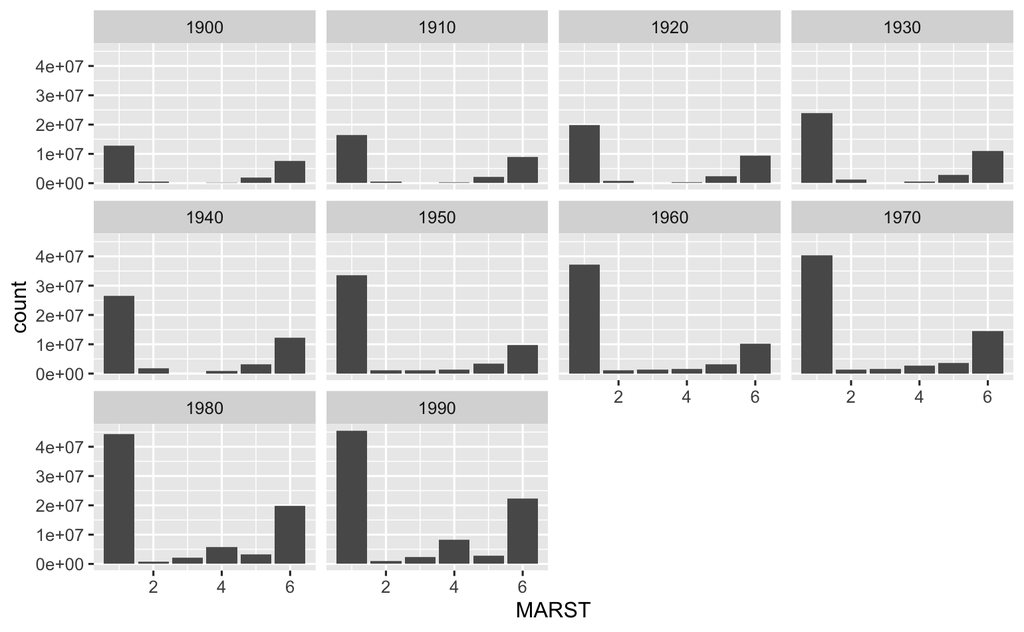

```r
ggplot(women,aes(MARST,weight=PERWT)) + geom_bar() + facet_wrap(vars(YEAR))
```

Now let’s make a data set called `allwomen` that includes all women under 90 (take a look at the documentation for `AGE` to see why I chose this cutoff). We will recode `MARST` into a new variable called `MARITAL` with four categories: single (never married), married, divorced (including separated and spouse absent), and widowed. Make a scatterplot to test whether you did the recoding correctly.

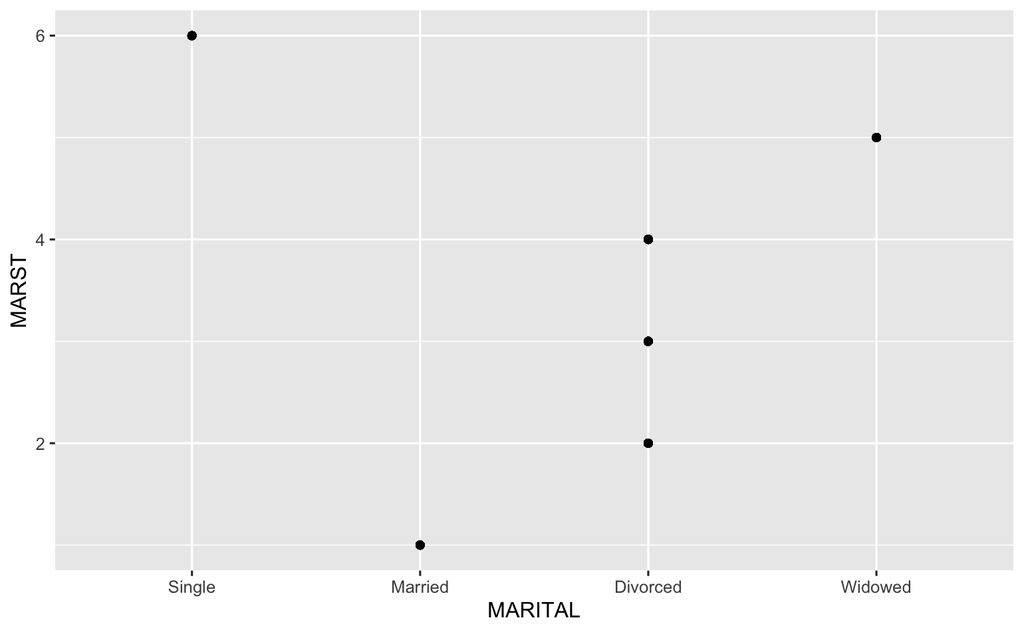

```r
allwomen <- ipums %>% filter (SEX == 2 & AGE < 90) %>%
mutate(MARITAL = ifelse(MARST == 6,1,
                 ifelse(MARST == 1,2,
                 ifelse(MARST == 5,4,3)))) %>%
mutate(MARITAL = factor(MARITAL,labels = c("Single", "Married", "Divorced", "Widowed")))
qplot(MARITAL, MARST, data = allwomen)
```

Since we want to graph the *percent* of women at each age who are in each marital status category, rather than the *number*, we need to calculate the number of women at each age in each year who are in each marital status category and the total number of women at each age in each year. We do this by moving the `MARITAL` variable from our `group_by()` function to our `count()` function and then adding a mutate function that uses the `sum()` function that calculates the total number of women in each year/age group by summing the number of women in each marital status in each year/age group, which was calculated in the `count()` function.

```r
maritalpct <- allwomen %>% group_by(YEAR, AGE) %>%
                count(MARITAL, wt = PERWT) %>%
                mutate(TOTAL = sum(n))
```

[output not shown]

What this line says is: take the `allwomen` data frame; for each census year and each unique value of `AGE` , count the number of records with each unique value of `MARITAL`, weighting by `PERWT` (this becomes a new variable, `n`); then create a new variable called `TOTAL`, which is the sum of `n` for all rows with the same value of `YEAR` and `AGE`.

Now we can use this data frame to make a line graph. Note that it looks just like our column graphs, but with `geom_line()` instead of `geom_col()` and `color` instead of `fill`. We can control all aspects of it the same way we did with our column graphs.

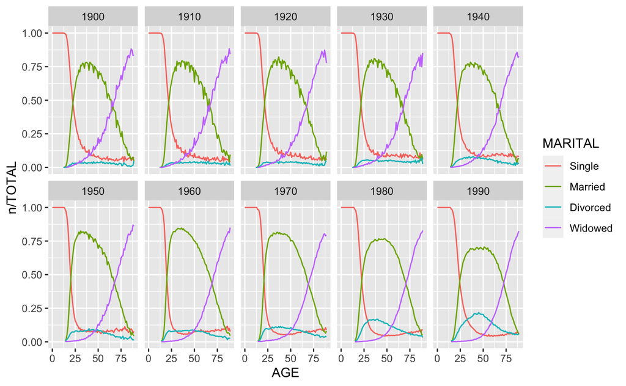

```r
ggplot(maritalpct, aes(AGE, n/TOTAL, color = MARITAL)) + geom_line() +
  facet_wrap(vars(YEAR), ncol = 5)
```

We have successfully replicated the graph from *Business Insider*, but it is not actually a very good way to see change over time in marital status. To begin with, there is good reason to think that these patterns vary by race. The issue with this visualization, however, is that all the lines add up to 1 because they all have the total population as the denominator. A better way to visualize this is with an area graph, where we can see the changing proportions of the population:

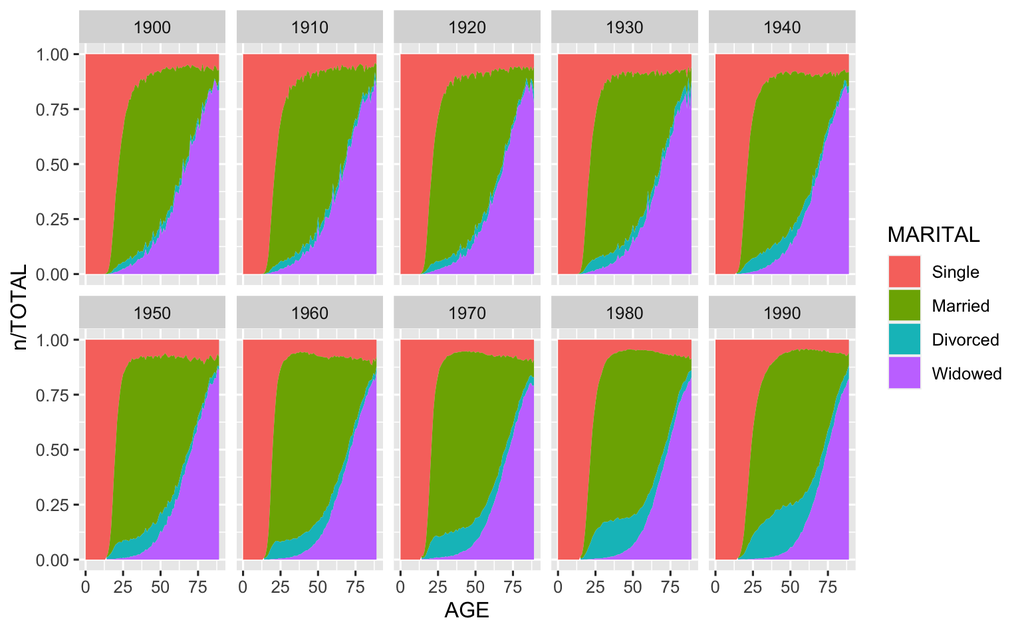

```r
ggplot(maritalpct, aes(AGE, n/TOTAL, fill = MARITAL)) + geom_area() +
  facet_wrap(vars(YEAR), ncol = 5)
```

What line graphs are really good for are comparisons between groups, where the denominator is different. Run this code:

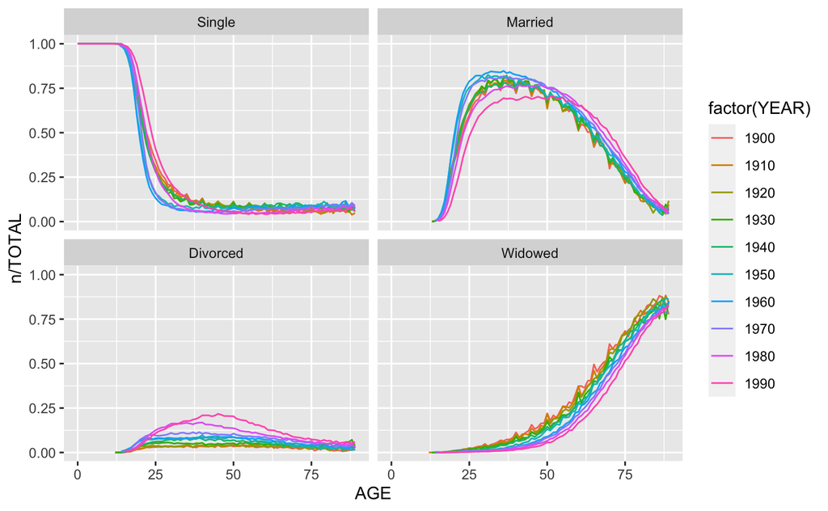

```r
ggplot(maritalpct, aes(AGE, n/TOTAL, color = factor(YEAR))) + geom_line() +
  facet_wrap(vars(MARITAL))
```

This is exactly the same as the code for our previous line graph, but we have swapped `MARITAL` and `YEAR`, so now line color represents `YEAR` (we had to factor `YEAR`) and we have faceted by marital status. This way we can see change over time in the proportion of women at each age who are single, married, divorced, and widowed. Change over time is even easier to see with fewer lines. Do the same thing, but only for 1900, 1930, 1960, and 1990:

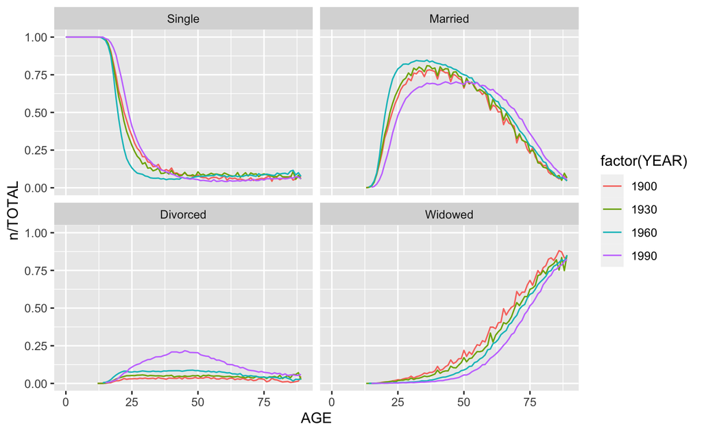

```r
ggplot(filter(maritalpct, YEAR %in% c(1900,1930,1960,1990)),aes(AGE, n/TOTAL, color = factor(YEAR))) + geom_line() +
  facet_wrap(vars(MARITAL))
```

We can also add race to the graph to see how these patterns differed for women of different racial categories. Start by creating a variable in `allwomen` called `RACEF` that classifies women as either white, black, or other.

```r
allwomen <- allwomen %>% mutate(RACEF = ifelse(RACE >2,3,RACE)) %>%
mutate (RACEF = factor(RACEF, labels=c("White","Black", "Other")))
table(allwomen$RACEF)
```

```
  White   Black   Other
6913281  894066  159044
```

Now make the same graph, but facet by `RACEF` as well as `MARITAL`.

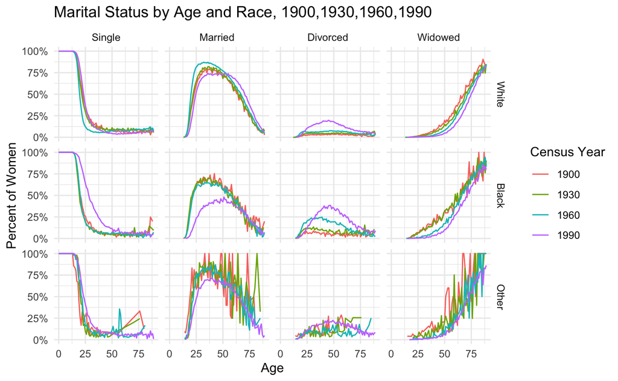

```r
allwomen %>% filter(YEAR %in% c(1900,1930,1960,1990)) %>% group_by(YEAR,AGE,RACEF) %>%
count (MARITAL,wt=PERWT) %>% mutate (TOTAL = sum(n)) %>% ggplot (aes(AGE,n/TOTAL,color = factor (YEAR))) + geom_line() + facet_grid(cols = vars(MARITAL), rows=vars(RACEF)) + theme_minimal() + scale_y_continuous(labels = scales::percent) +labs(x="Age",y="Percent of Women", color="Census Year", title="Marital Status by Age and Race, 1900,1930,1960,1990")
```

## Submit your notebook

Save and preview this file. Make sure everything is showing up (if it isn’t, try running the code again). Upload the .nb.html file to Canvas. You are now ready to complete Lab 5!